# Claim Frequency Modeling

Ciwon Kang

2026-06-30

## *1) Overview*

This project models **claim frequency** using the **freMTPL2freq** dataset.  
We compare two modeling approaches:  
- 1. Poisson GLM  
- 2. Negative Binomial GLM

The goal is to identify an appropriate model for predicting the expected number of insurance claims while accounting for differences in policy exposure.

## *2) Data Exploration*

```r
library(CASdatasets)
data(freMTPL2freq)
```

```r
Autofreq<-freMTPL2freq
head(Autofreq)
```

```
##   IDpol ClaimNb Exposure VehPower VehAge DrivAge BonusMalus VehBrand  VehGas
## 1     1       0     0.10        5      0      55         50      B12 Regular
## 2     3       0     0.77        5      0      55         50      B12 Regular
## 3     5       0     0.75        6      2      52         50      B12  Diesel
## 4    10       0     0.09        7      0      46         50      B12  Diesel
## 5    11       0     0.84        7      0      46         50      B12  Diesel
## 6    13       0     0.52        6      2      38         50      B12 Regular
##   Area Density             Region
## 1    D    1217        Rhone-Alpes
## 2    D    1217        Rhone-Alpes
## 3    B      54           Picardie
## 4    B      76          Aquitaine
## 5    B      76          Aquitaine
## 6    E    3003 Nord-Pas-de-Calais
```

```r
str(Autofreq)
```

```
## 'data.frame':    677991 obs. of  12 variables:
##  $ IDpol     : Factor w/ 677991 levels "1","3","5","10",..: 1 2 3 4 5 6 7 8 9 10 ...
##  $ ClaimNb   : num  0 0 0 0 0 0 0 0 0 0 ...
##  $ Exposure  : num  0.1 0.77 0.75 0.09 0.84 0.52 0.45 0.27 0.71 0.15 ...
##  $ VehPower  : int  5 5 6 7 7 6 6 7 7 7 ...
##  $ VehAge    : int  0 0 2 0 0 2 2 0 0 0 ...
##  $ DrivAge   : int  55 55 52 46 46 38 38 33 33 41 ...
##  $ BonusMalus: int  50 50 50 50 50 50 50 68 68 50 ...
##  $ VehBrand  : Factor w/ 11 levels "B1","B10","B11",..: 4 4 4 4 4 4 4 4 4 4 ...
##  $ VehGas    : Factor w/ 2 levels "Diesel","Regular": 2 2 1 1 1 2 2 1 1 1 ...
##  $ Area      : Factor w/ 6 levels "A","B","C","D",..: 4 4 2 2 2 5 5 3 3 2 ...
##  $ Density   : int  1217 1217 54 76 76 3003 3003 137 137 60 ...
##  $ Region    : Factor w/ 22 levels "Alsace","Aquitaine",..: 22 22 19 2 2 17 17 13 13 18 ...
```

```r
summary(Autofreq)
```

```
##      IDpol           ClaimNb          Exposure           VehPower
##  1      :     1   Min.   : 0.000   Min.   :0.002732   Min.   : 4.000
##  3      :     1   1st Qu.: 0.000   1st Qu.:0.180000   1st Qu.: 5.000
##  5      :     1   Median : 0.000   Median :0.490000   Median : 6.000
##  10     :     1   Mean   : 0.039   Mean   :0.528743   Mean   : 6.455
##  11     :     1   3rd Qu.: 0.000   3rd Qu.:0.990000   3rd Qu.: 7.000
##  13     :     1   Max.   :16.000   Max.   :2.010000   Max.   :15.000
##  (Other):677985
##      VehAge           DrivAge        BonusMalus        VehBrand
##  Min.   :  0.000   Min.   : 18.0   Min.   : 50.00   B12    :166022
##  1st Qu.:  2.000   1st Qu.: 34.0   1st Qu.: 50.00   B1     :162730
##  Median :  6.000   Median : 44.0   Median : 50.00   B2     :159854
##  Mean   :  7.044   Mean   : 45.5   Mean   : 59.76   B3     : 53393
##  3rd Qu.: 11.000   3rd Qu.: 55.0   3rd Qu.: 64.00   B5     : 34752
##  Max.   :100.000   Max.   :100.0   Max.   :230.00   B6     : 28545
##                                                     (Other): 72695
##      VehGas       Area          Density
##  Diesel :332128   A:103952   Min.   :    1
##  Regular:345863   B: 75457   1st Qu.:   92
##                   C:191874   Median :  393
##                   D:151592   Mean   : 1792
##                   E:137163   3rd Qu.: 1658
##                   F: 17953   Max.   :27000
##
##                          Region
##  Centre                     :160595
##  Rhone-Alpes                : 84748
##  Provence-Alpes-Cotes-D'Azur: 79315
##  Ile-de-France              : 69789
##  Bretagne                   : 42120
##  Pays-de-la-Loire           : 38747
##  (Other)                    :202677
```

**Variables:**

- `ClaimNb`: Number of insurance claims (Response variable)
- `Exposure`: Length of policy exposure (in years)
- `VehPower`: Vehicle power category
- `VehAge`: Vehicle age
- `DrivAge`: Driver age
- `BonusMalus`: Bonus-malus rating
- `VehBrand`: Vehicle brand category
- `VehGas`: Fuel type
- `Density`: Population density
- `Region`: Geographic region

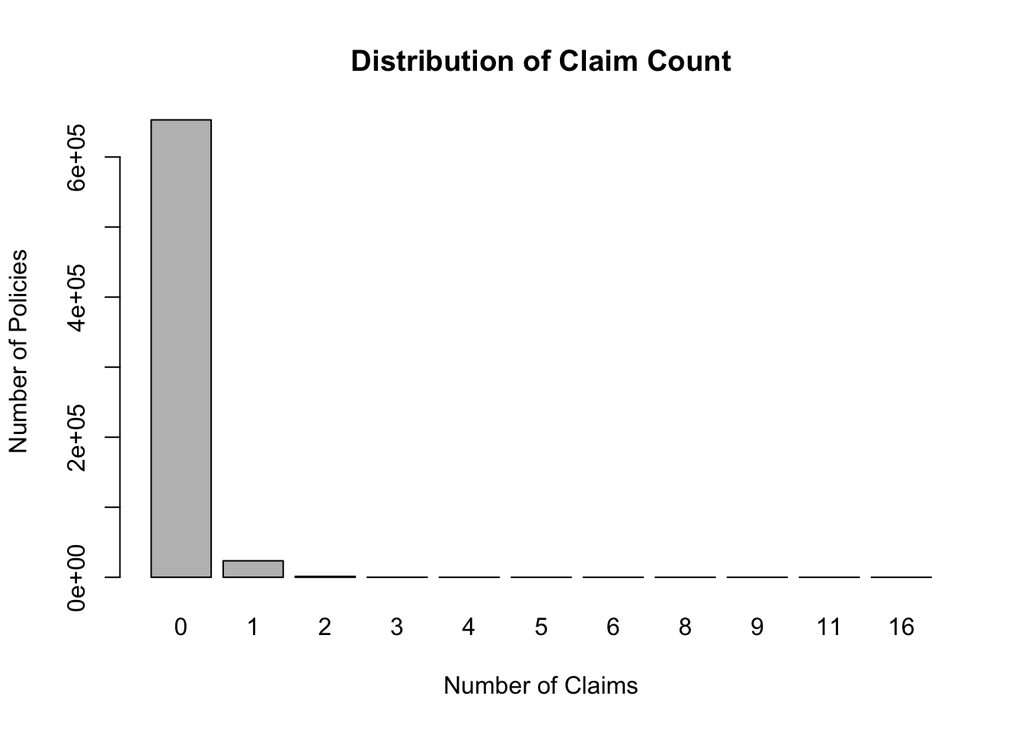

```r
claim_counts <- table(Autofreq$ClaimNb)

barplot(claim_counts,
        main = "Distribution of Claim Count",
        xlab = "Number of Claims",
        ylab = "Number of Policies")
```

```r
mean(Autofreq$ClaimNb)
```

```
## [1] 0.03900347
```

```r
var(Autofreq$ClaimNb)
```

```
## [1] 0.04291891
```

```r
mean(Autofreq$ClaimNb == 0)
```

```
## [1] 0.963209
```

**Observation:**  
- ClaimNb represents the number of insurance claims and is used as the response variable. The remaining variables describe policyholder, vehicle, and geographic characteristics that may influence claim frequency.

- Most policyholders have no claims (96%), while only a small proportion experience one or more claims. The average claim frequency is low (0.039 claims per policy), indicating that insurance claims are relatively rare events. The variance is slightly larger than the mean, suggesting that the Poisson assumption of equal mean and variance should be evaluated further.

## *3) Model 1 : Poisson GLM*

### **3.1 Model fitting**

```r
model1<-glm(ClaimNb~.-IDpol-Exposure+offset(log(Exposure)),
            family=poisson(link='log'),
            data=Autofreq)
summary(model1)
```

```
##
## Call:
## glm(formula = ClaimNb ~ . - IDpol - Exposure + offset(log(Exposure)),
##     family = poisson(link = "log"), data = Autofreq)
##
## Coefficients:
##                                     Estimate Std. Error z value Pr(>|z|)
## (Intercept)                       -4.718e+00  1.150e-01 -41.008  < 2e-16 ***
## VehPower                           3.480e-02  3.286e-03  10.591  < 2e-16 ***
## VehAge                            -1.752e-02  1.282e-03 -13.667  < 2e-16 ***
## DrivAge                            5.699e-03  4.613e-04  12.355  < 2e-16 ***
## BonusMalus                         2.618e-02  3.329e-04  78.641  < 2e-16 ***
## VehBrandB10                       -9.782e-03  3.949e-02  -0.248 0.804344
## VehBrandB11                        1.510e-01  4.173e-02   3.618 0.000296 ***
## VehBrandB12                       -3.224e-01  2.202e-02 -14.638  < 2e-16 ***
## VehBrandB13                        3.840e-02  4.501e-02   0.853 0.393585
## VehBrandB14                       -2.030e-01  8.831e-02  -2.299 0.021522 *
## VehBrandB2                        -1.234e-02  1.713e-02  -0.720 0.471372
## VehBrandB3                         4.117e-02  2.381e-02   1.729 0.083796 .
## VehBrandB4                         1.732e-02  3.263e-02   0.531 0.595683
## VehBrandB5                         7.796e-02  2.739e-02   2.846 0.004424 **
## VehBrandB6                         3.092e-02  3.084e-02   1.002 0.316151
## VehGasRegular                     -1.662e-01  1.272e-02 -13.067  < 2e-16 ***
## AreaB                              9.362e-02  2.636e-02   3.552 0.000383 ***
## AreaC                              1.647e-01  2.181e-02   7.551 4.33e-14 ***
## AreaD                              3.114e-01  2.310e-02  13.484  < 2e-16 ***
## AreaE                              3.939e-01  3.008e-02  13.094  < 2e-16 ***
## AreaF                              4.557e-01  1.037e-01   4.395 1.11e-05 ***
## Density                           -1.336e-06  4.276e-06  -0.313 0.754608
## RegionAquitaine                    8.339e-02  1.088e-01   0.766 0.443396
## RegionAuvergne                    -2.046e-02  1.343e-01  -0.152 0.878910
## RegionBasse-Normandie              5.953e-03  1.145e-01   0.052 0.958546
## RegionBourgogne                    3.479e-02  1.176e-01   0.296 0.767362
## RegionBretagne                     2.093e-02  1.070e-01   0.196 0.844991
## RegionCentre                       1.047e-02  1.054e-01   0.099 0.920888
## RegionChampagne-Ardenne            1.062e-02  1.547e-01   0.069 0.945283
## RegionCorse                        1.542e-01  1.363e-01   1.131 0.258053
## RegionFranche-Comte               -3.669e-02  1.930e-01  -0.190 0.849216
## RegionHaute-Normandie              8.650e-03  1.242e-01   0.070 0.944494
## RegionIle-de-France                4.170e-02  1.070e-01   0.390 0.696859
## RegionLanguedoc-Roussillon         6.530e-02  1.089e-01   0.600 0.548582
## RegionLimousin                     3.678e-01  1.268e-01   2.902 0.003708 **
## RegionLorraine                    -1.070e-01  1.143e-01  -0.936 0.349448
## RegionMidi-Pyrenees               -2.133e-01  1.167e-01  -1.828 0.067604 .
## RegionNord-Pas-de-Calais           3.964e-02  1.094e-01   0.362 0.717045
## RegionPays-de-la-Loire             5.375e-02  1.074e-01   0.500 0.616753
## RegionPicardie                     1.405e-01  1.187e-01   1.184 0.236380
## RegionPoitou-Charentes             7.505e-02  1.104e-01   0.680 0.496680
## RegionProvence-Alpes-Cotes-D'Azur  1.478e-01  1.059e-01   1.396 0.162619
## RegionRhone-Alpes                  2.293e-01  1.055e-01   2.173 0.029754 *
## ---
## Signif. codes:  0 '***' 0.001 '**' 0.01 '*' 0.05 '.' 0.1 ' ' 1
##
## (Dispersion parameter for poisson family taken to be 1)
##
##     Null deviance: 171817  on 677990  degrees of freedom
## Residual deviance: 164703  on 677948  degrees of freedom
## AIC: 215558
##
## Number of Fisher Scoring iterations: 6
```

**Observation:**  
Poisson GLM is first used as a baseline model for insurance claim frequency. The model uses a log link and accounts for differences in policy exposure through an offset term, allowing claim frequencies to be compared on a common annual basis.

### **3.2 Actual vs Predicted claims**

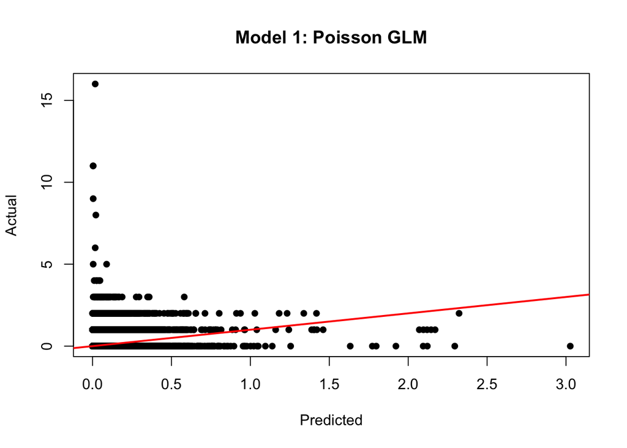

```r
plot(predict(model1, type = "response"),
     Autofreq$ClaimNb,
     main = "Model 1: Poisson GLM",
     xlab = "Predicted",
     ylab = "Actual",
     pch = 16)

abline(a = 0, b = 1, col = "red", lwd = 2)
```

**Observation:**  
Most observations are concentrated near zero, reflecting the rarity of insurance claims. While the Poisson GLM captures the overall claim frequency, it has limited ability to represent policies with multiple claims.

### **3.3 Limitations**

#### **3.3.1 Mean-Variance Assumption**

- Poisson GLM assumes that the mean and variance of the response variable are equal. This assumption should be evaluated because insurance claim counts often exhibit greater variability than expected under a Poisson distribution.

#### **3.3.2 Overdispersion**

```r
dispersion <- sum(residuals(model1, type = "pearson")^2) /
              df.residual(model1)

dispersion
```

```
## [1] 1.823508
```

## *4) Model 2 : Negative Binomial GLM*

### **4.1 Model fitting**

- Although the Poisson GLM provides a reasonable baseline model for claim frequency, it assumes that the mean and variance of the response are equal. The dispersion statistic indicates moderate overdispersion, suggesting that the Poisson model underestimates the variability in claim counts. Negative Binomial GLM relaxes this assumption by allowing the variance to exceed the mean, making it more appropriate for insurance claim frequency data.

```r
library(MASS)

model2 <- glm.nb(
  ClaimNb ~ . - IDpol - Exposure + offset(log(Exposure)),
  data = Autofreq
)

summary(model2)
```

```
##
## Call:
## glm.nb(formula = ClaimNb ~ . - IDpol - Exposure + offset(log(Exposure)),
##     data = Autofreq, init.theta = 1.003583378, link = log)
##
## Coefficients:
##                                     Estimate Std. Error z value Pr(>|z|)
## (Intercept)                       -4.755e+00  1.199e-01 -39.675  < 2e-16 ***
## VehPower                           3.472e-02  3.390e-03  10.242  < 2e-16 ***
## VehAge                            -1.743e-02  1.322e-03 -13.190  < 2e-16 ***
## DrivAge                            5.880e-03  4.830e-04  12.175  < 2e-16 ***
## BonusMalus                         2.655e-02  3.649e-04  72.759  < 2e-16 ***
## VehBrandB10                       -1.019e-02  4.083e-02  -0.250 0.802891
## VehBrandB11                        1.486e-01  4.335e-02   3.428 0.000607 ***
## VehBrandB12                       -3.209e-01  2.264e-02 -14.176  < 2e-16 ***
## VehBrandB13                        3.382e-02  4.666e-02   0.725 0.468515
## VehBrandB14                       -2.078e-01  9.080e-02  -2.289 0.022083 *
## VehBrandB2                        -1.220e-02  1.770e-02  -0.690 0.490472
## VehBrandB3                         4.130e-02  2.466e-02   1.675 0.093951 .
## VehBrandB4                         1.908e-02  3.374e-02   0.566 0.571639
## VehBrandB5                         8.246e-02  2.840e-02   2.904 0.003685 **
## VehBrandB6                         3.349e-02  3.189e-02   1.050 0.293742
## VehGasRegular                     -1.674e-01  1.314e-02 -12.744  < 2e-16 ***
## AreaB                              9.405e-02  2.705e-02   3.477 0.000507 ***
## AreaC                              1.659e-01  2.239e-02   7.409 1.27e-13 ***
## AreaD                              3.149e-01  2.376e-02  13.251  < 2e-16 ***
## AreaE                              3.975e-01  3.106e-02  12.799  < 2e-16 ***
## AreaF                              4.676e-01  1.074e-01   4.354 1.34e-05 ***
## Density                           -1.521e-06  4.434e-06  -0.343 0.731592
## RegionAquitaine                    8.890e-02  1.129e-01   0.787 0.431229
## RegionAuvergne                    -1.175e-02  1.386e-01  -0.085 0.932475
## RegionBasse-Normandie              1.594e-02  1.189e-01   0.134 0.893319
## RegionBourgogne                    4.339e-02  1.220e-01   0.356 0.722077
## RegionBretagne                     3.053e-02  1.112e-01   0.275 0.783571
## RegionCentre                       1.672e-02  1.095e-01   0.153 0.878633
## RegionChampagne-Ardenne            1.943e-02  1.593e-01   0.122 0.902911
## RegionCorse                        1.663e-01  1.407e-01   1.182 0.237294
## RegionFranche-Comte               -1.886e-02  1.980e-01  -0.095 0.924140
## RegionHaute-Normandie              1.894e-02  1.285e-01   0.147 0.882823
## RegionIle-de-France                4.830e-02  1.111e-01   0.435 0.663863
```

[output cut: 11 more lines]

```
## Signif. codes:  0 '***' 0.001 '**' 0.01 '*' 0.05 '.' 0.1 ' ' 1
##
## (Dispersion parameter for Negative Binomial(1.0036) family taken to be 1)
##
##     Null deviance: 150874  on 677990  degrees of freedom
## Residual deviance: 144210  on 677948  degrees of freedom
## AIC: 214907
##
## Number of Fisher Scoring iterations: 1
##
##
##               Theta:  1.0036
##           Std. Err.:  0.0526
##
##  2 x log-likelihood:  -214818.9460
```

**Observation:**  
The Negative Binomial GLM extends the Poisson model by introducing an additional dispersion parameter, allowing the variance to exceed the mean. This provides greater flexibility for modeling insurance claim counts when overdispersion is present.

### **4.2 Actual vs Predicted Claims**

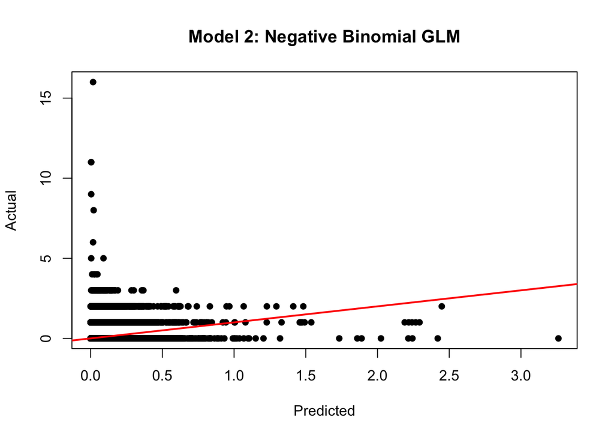

```r
plot(
  predict(model2, type = "response"),
  Autofreq$ClaimNb,
  main = "Model 2: Negative Binomial GLM",
  xlab = "Predicted",
  ylab = "Actual",
  pch = 16
)

abline(a = 0, b = 1, col = "red", lwd = 2)
```

**Observation:**  
The predicted claim counts remain concentrated near zero, reflecting the rarity of insurance claims. Similar to the Poisson model, the Negative Binomial GLM has difficulty visually distinguishing the relatively small number of policies with multiple claims. Its improvement is evaluated more clearly through the dispersion structure and AIC.

### **4.3 Model Performance**

```r
AIC(model1, model2)
```

```
##        df      AIC
## model1 43 215557.6
## model2 44 214906.9
```

**Observation:**  
The Negative Binomial GLM has a lower AIC than the Poisson GLM, indicating a better balance between model fit and complexity. This suggests that allowing for overdispersion improves the model’s ability to explain the observed claim frequencies.

### **4.4 Dispersion Parameter**

```r
model2$theta
```

```
## [1] 1.003583
```

## *5) Model Comparison*

```r
comparison <- data.frame(
  Model = c("Poisson GLM",
            "Negative Binomial GLM"),
  AIC = c(AIC(model1),
          AIC(model2))
)

comparison
```

```
##                   Model      AIC
## 1           Poisson GLM 215557.6
## 2 Negative Binomial GLM 214906.9
```

**Observation:**  
The Negative Binomial GLM achieved a lower AIC than the Poisson GLM, indicating a better overall fit while accounting for overdispersion. Therefore, it is selected as the final model for claim frequency.

## *6) Conclusion*

This project compared Poisson and Negative Binomial GLMs for modeling insurance claim frequency.

The Poisson GLM served as a useful baseline model but assumed that the mean and variance of the response were equal. The estimated dispersion statistic indicated moderate overdispersion, suggesting that this assumption was not fully satisfied.

The Negative Binomial GLM addressed this limitation by allowing the variance to exceed the mean and achieved a lower AIC than the Poisson model. Therefore, the Negative Binomial GLM was selected as the final model for predicting insurance claim frequency.